# 320d Austin Animal Center Report

## Data Analysis and Visualization

### Addressing project requirements

- Using visualizations published on Superset, explain your answers to the project requirements. Download your dashboard as an image and include a discussion of how the visualization answers your project requirements. Also include a link directly to your dashboard on Superset (for interactive exploration).
1. What is the average number of days in AAC for an animal? (1) Average Number of Days in AAC by Animal Type

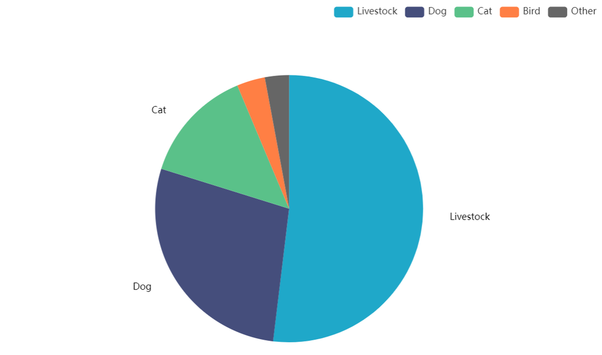

The visualization for the average number of days in the Austin Animal Center for an animal by animal type answers the project requirements by illustrating the average number of days in the center by animal center in a pie graph. This pie graph displays the relative size of the average number of days when comparing one animal type to another. The metric AVG(days_in_shelter) and the dimension animal_type build the visualization to address the question. As we can see, livestock animals tend to have the longest stays in the shelter. It is important to rememeber that the sample size for livestock animals is significantly smaller than the other categories, so this number may not be representative of all livestock animals and the average number of days spent during an animal shelter stay.

(2)Average Number of Days in AAC by Type and Breed

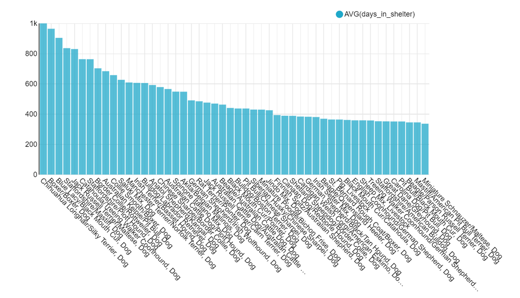

(3)Average Days By Year And Animal Type

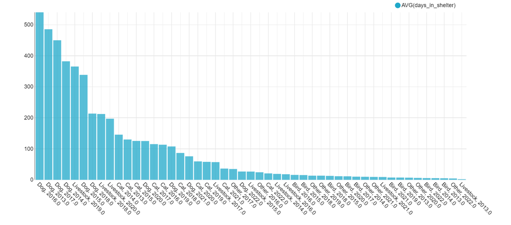

The visualization for the average number of days in the Austin Animal Center for an animal by year and by animal type answers the project requirements by using a bar graph to display the average number of days in the animal center by year and by animal type together. The metric (AVG days_in_shelter) and the dimensions date_part and animal_type build the visualization to address the question.

2.Number of Intakes and Outcomes Per Year

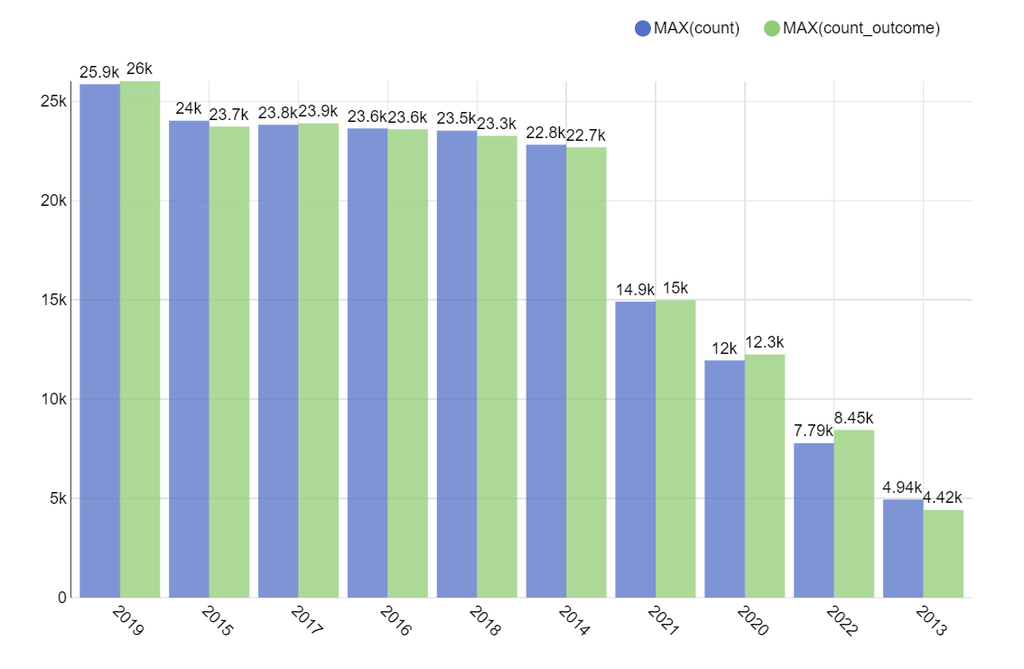

3.Number of Intakes Per Month

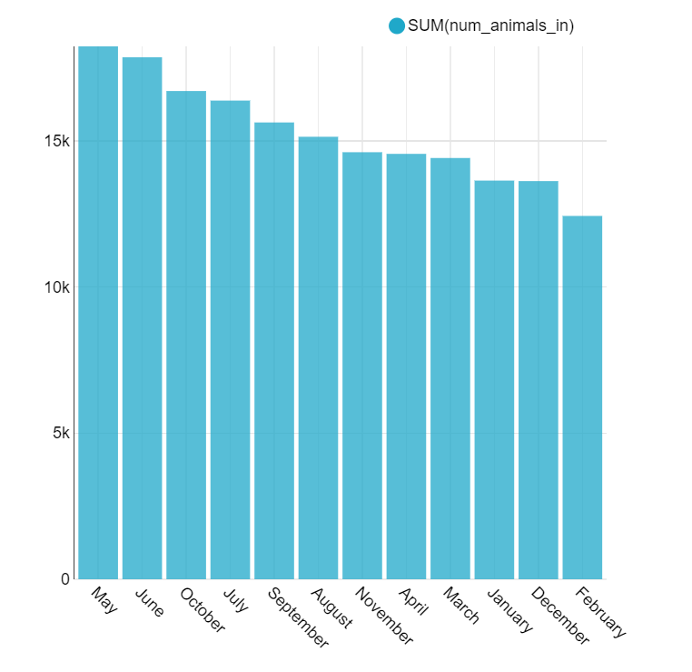

Using a bar graph for the sum of the number of intakes each month, the visualization and answers the project requirements as the client can see the three months with the highest intake for the busiest months. The busiest months are May, June, and October and the slowest months are January, December, and February.

4.Adoptions by Animal Type

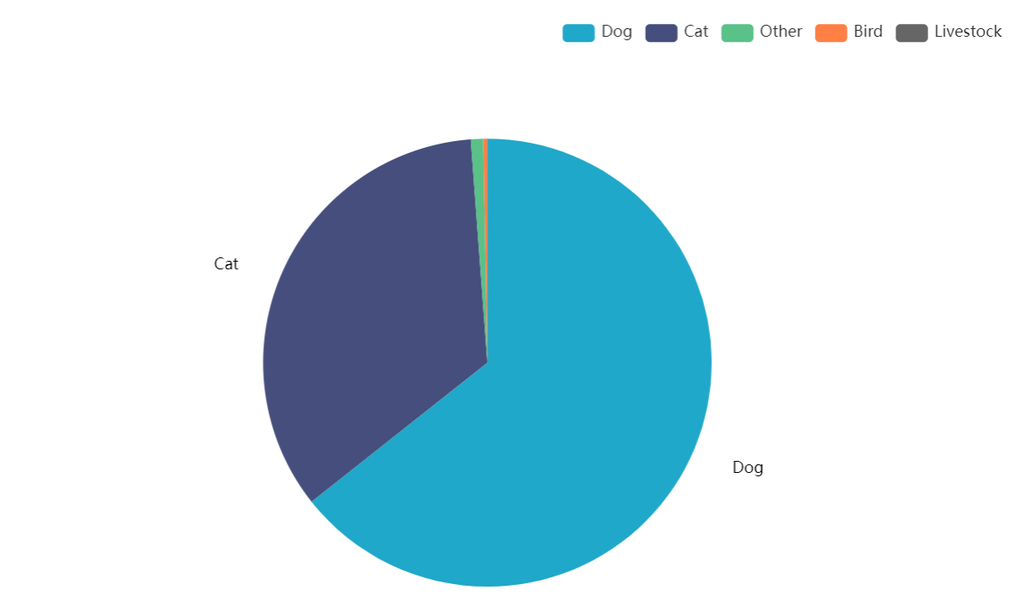

The visualization for the adoptions by animal type answers the project requirements by using a pie chart to show the number of each animal type that was adopted and the relative magnitude of the number of adoptions compared to others. Here, we can see that out of all adoptions, almost 2/3 of all adoptions are for dogs. This may suggest that dogs are the most likely animals to get adopted.

## Document your visualization decisions

- Explain the visualization options you considered and why your group decided that these particular visualizations were most appropriate to answer the questions.
- Explain your choice of colorscheme (if used).
- Explain how you aligned your data product(s) to make them align with your visualizations (e.g., what aliases did you createin the data products)

There are many options for visualizations like pie charts, line graphs, and bar charts. We used a pie chart for 'Average Number of Days in AAC by Animal Type' and 'Adoptions by Animal Type' since both have only two variables (e.g. for 'Average Number of Days in AAC by Animal Type', two variables are average number of days in AAC and animal type) and a pie chart is very effective at measuring the relationship between two variables. The radius of the circle can be made proportional to the quantity of animal type, so it's easy to compare the average number of days in AAC and adoptions among different animal types. We chose a bar chart to measure the Average Number of Days in AAC by Type and Breed, Average Days By Year And Animal Type, Number of Intakes and Outcomes Per Year and Number of Intakes Per Month since we want to know the several highest results, and in the bar chart we can range them in a descending order so it's easy to grab the data the client wants.

We choose different color if there is a clear comparison like intakes verses outcomes per year in 'Number of Intakes and Outcomes Per Year'. For pie chart, we use bright color for small proportional data to make it obvious.

For 'Average Number of Days in AAC by Animal Type', we choose animal_type and days_in_shelter as aliases, different colors represent animal_type and proprtional of circle represent days_in_shelter; for 'Average Number of Days in AAC by Type and Breed', aliases are animal_type, animal_breed, days_in_shelter, where animal_type, animal_breed are on the x axies and days_in_shelter are on the y axies ; for 'Average Days By Year And Animal Type', aliases are animal_type, year from intake_time and days_in_shelter, where animal_type, year from intake_time are on the x axies and days_in_shelter is on the y axies; for 'Number of Intakes and Outcomes Per Year', aliases are year_intake, year_outcome and animal id, where for each year on the axies, there are year_intake, year_outcome as two different height bars ; for 'Number of Intakes Per Month', aliases are month and num_animals_in, where different months are on x axies and num_animals_in are on y axies ; for 'Adoptions by Animal Type', aliases are num_adoptions and animal_type, where different colors represent animal_type and proprtional of circle represent num_adoptions.

## Reflection and challenges addressed

In about 200 words describe the challenges that your group faced with their project and how they were addressed.

Include a few sentences that celebrate the aspects of your project of which you are proud.

We learned about composite primary keys in this project. We discovered them from the data and validated our hypothesis by understanding the meaning of the ACC animal intake and outcome processes. We noticed there were duplicated attributes in different tables like outcome type and suboutcome type, so we did some normalization in the star schema. We also learend about the differences between keeping four dimensions instaed of three, although both are correct here.